# Course Project 1

### Load the data

```r
f <- file.path(getwd(), "activity.csv")
data <- read.csv(f)
```

### Calculate the mean total number of steps taken per day

Calculate the total number of steps taken per day

```r
total_steps <- with(data, aggregate(steps, by = list(date), sum, na.rm = TRUE))
colnames(total_steps) <- c("date", "steps")
```

Make a histogram of the total number of steps taken each day

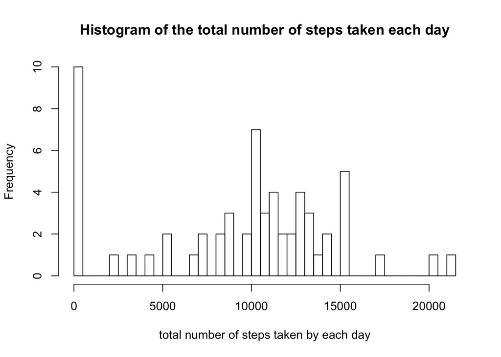

```r
with(total_steps, hist(steps, breaks = 62, main = "Histogram of the total number of steps taken each day", xlab = "total number of steps taken by each day"))
```

Calculate and report the mean and median of the total number of steps taken per day

```r
mean <- with(total_steps, mean(steps))
median <- with(total_steps, median(steps))
```

The mean of total number of steps taken per day is 9354.2295082  
The median of total number of steps taken per day is 10395

### Average daily activity pattern

```r
average_steps <- with(data, aggregate(steps, by = list(interval), mean, na.rm = TRUE))
colnames(average_steps) <- c("interval", "steps")
```

Plot the figure

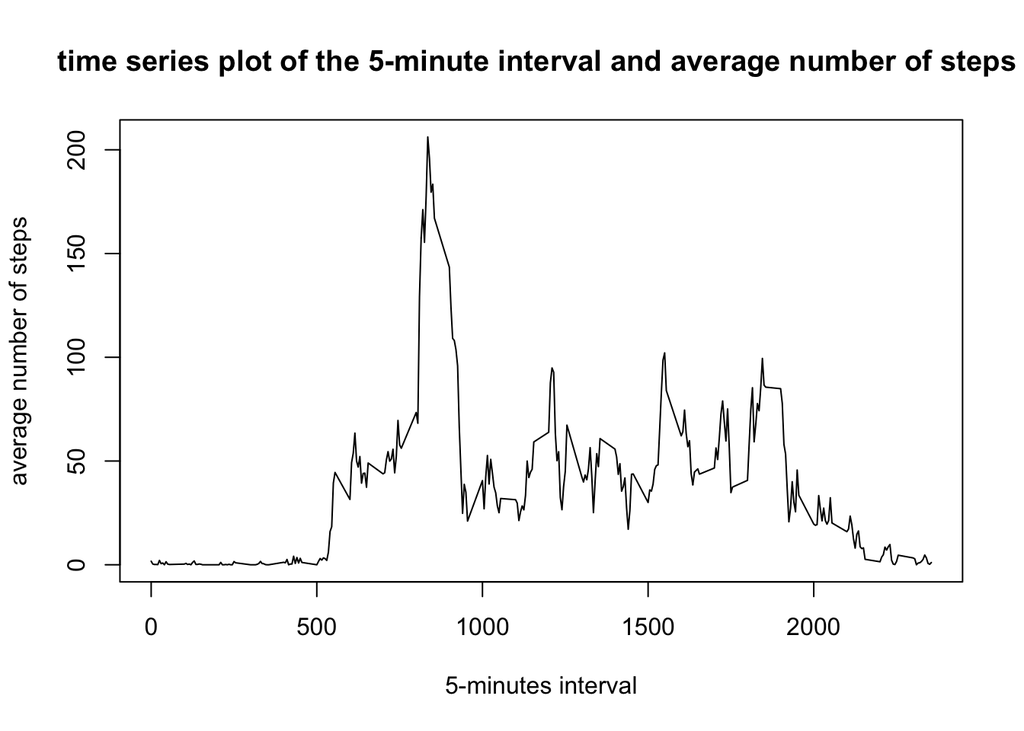

```r
with(average_steps, plot(interval, steps, type = "l", main = "time series plot of the 5-minute interval and average number of steps ", xlab = "5-minutes interval", ylab = "average number of steps"))
```

Find the 5-minute interval which has maximum average number of steps

```r
number <- which.max(average_steps$steps)
interval_max <- average_steps[which.max(average_steps$steps),][,1]
```

104th 5-minute interval which equals to 835, on average across all the days in the dataset, contains the maximum number of steps

### Imputing missing values

Calculate and report the total number of missing values in the dataset

```r
countNA <- sum(is.na(data$steps))
```

The total number of missing values in the dataset is 2304

Filling in all of the missing values in the dataset by the mean for that 5-minute interval

```r
replace <- rep(average_steps$steps, 61)
newdata <- data
newdata$steps[is.na(newdata$steps)] <- replace[is.na(newdata$steps)]
```

Make a histogram of the total number of steps taken each day

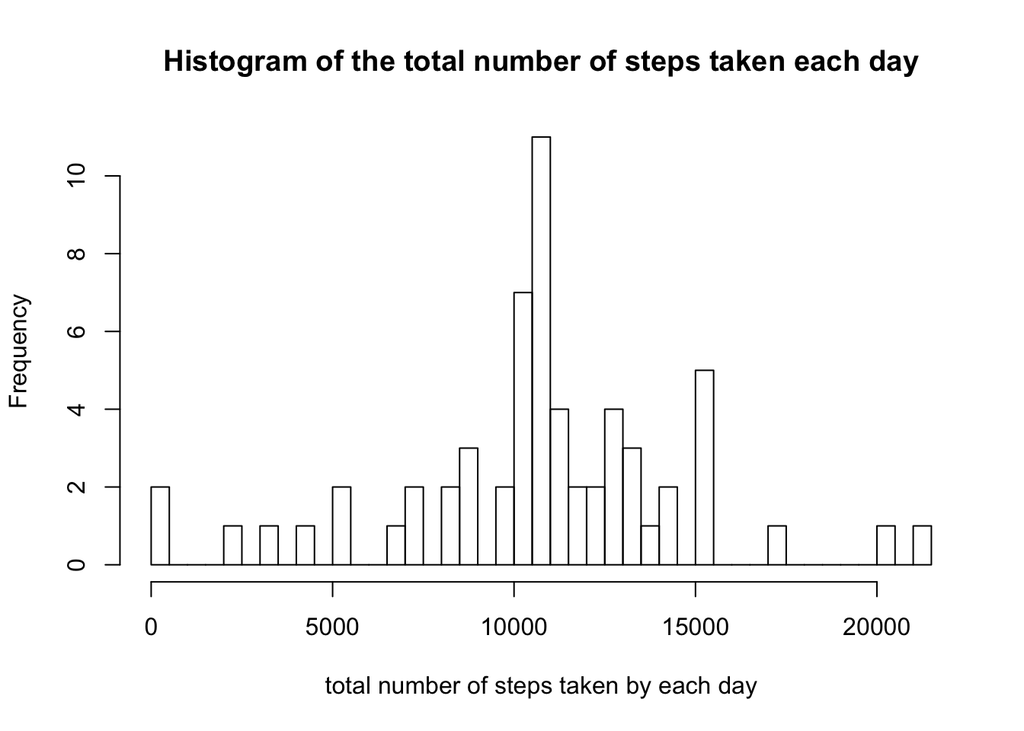

```r
newtotal_steps <- with(newdata, aggregate(steps, by = list(date), sum, na.rm = TRUE))
colnames(newtotal_steps) <- c("date", "steps")
with(newtotal_steps, hist(steps, breaks = 62, main = "Histogram of the total number of steps taken each day", xlab = "total number of steps taken by each day"))
```

```r
newmean <- with(newtotal_steps, mean(steps))
newmedian <- with(newtotal_steps, median(steps))
```

### Differences in activity patterns between weekdays and weekends

```r
newdata$date <- as.Date(newdata$date)
newfactor <- as.factor(weekdays(newdata$date))
levels(newfactor) <- list(Weekday = "Friday", Weekday = "Monday", Weekend = "Saturday", Weekend = "Sunday", Weekday = "Thursday", Weekday = "Tuesday", Weekday = "Wednesday")
newdata$week <- newfactor
```

Make a panel plot containing a time series plot of the 5-minute interval and the average number of steps taken

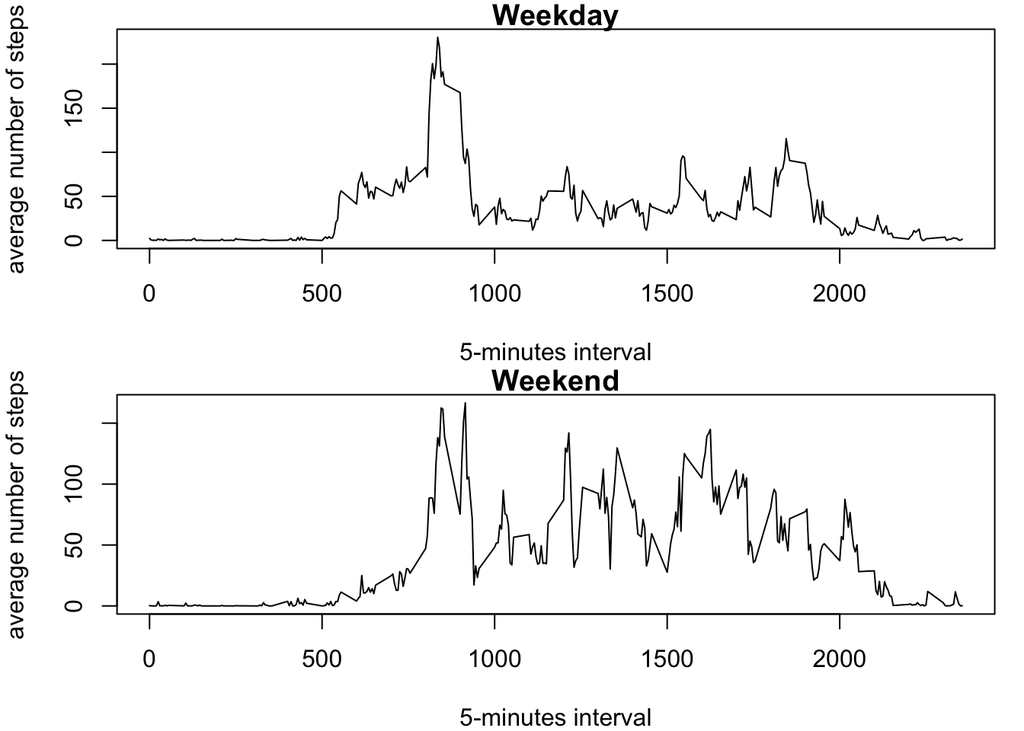

```r
par(mfrow = c(2,1), mar = c(4,4,1,1))
newdata_weekday <- newdata[newdata$week == "Weekday",]
average_steps_weekdays <- with(newdata_weekday, aggregate(steps, by = list(interval), mean))
colnames(average_steps_weekdays) <- c("interval",  "steps" )
with(average_steps_weekdays, plot(interval, steps, type = "l", main = "Weekday", xlab = "5-minutes interval", ylab = "average number of steps"))
newdata_weekend <- newdata[newdata$week == "Weekend",]
average_steps_weekend <- with(newdata_weekend, aggregate(steps, by = list(interval), mean))
colnames(average_steps_weekend) <- c( "interval", "steps")
with(average_steps_weekend, plot(interval, steps, type = "l", main = "Weekend", xlab = "5-minutes interval", ylab = "average number of steps"))
```